# Project3: Loan Data From Prosper

### Credit Worthiness Variable Dependence and Loan Completion Status

Adding LoanStatus as a color to the bivariate scattergrams might tell us something about the predictive power of the columns used in the model fit. Defaulted and chargedoff loans are to the lower left in the scattergram of CreditScoreRangeUpper versus OpenRevolvingAccounts.

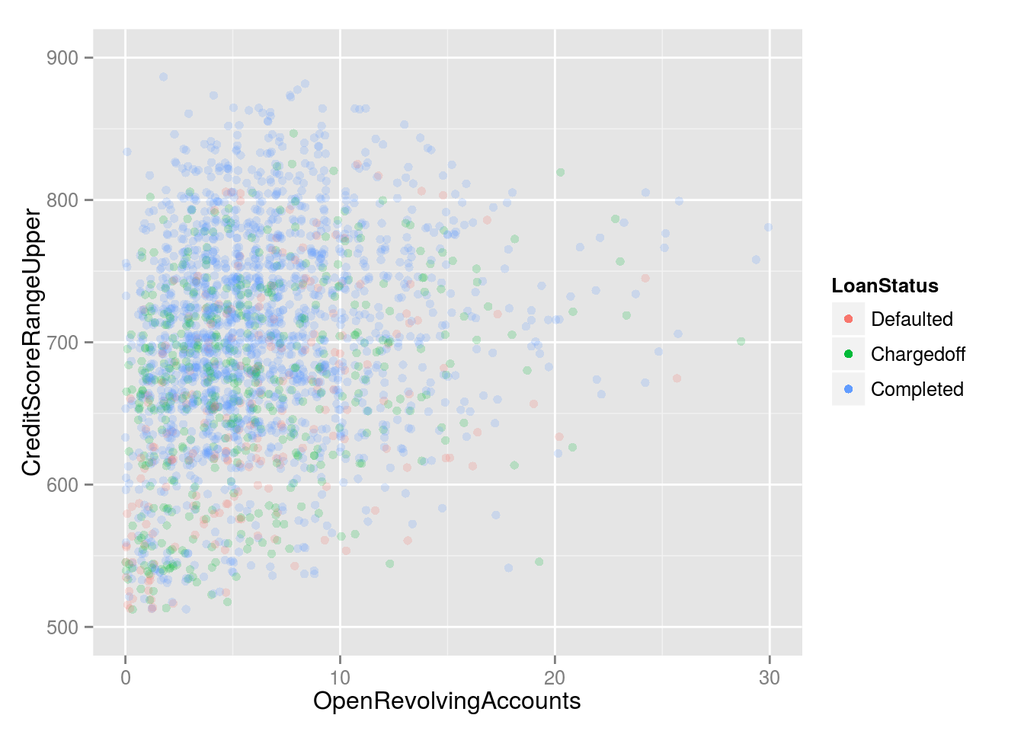

For the pairing of TotalCreditLinespast7years and OpenRevolvingAccounts, more of the separation by loan status seems to be accomplished by OpenRevolvingAccounts.

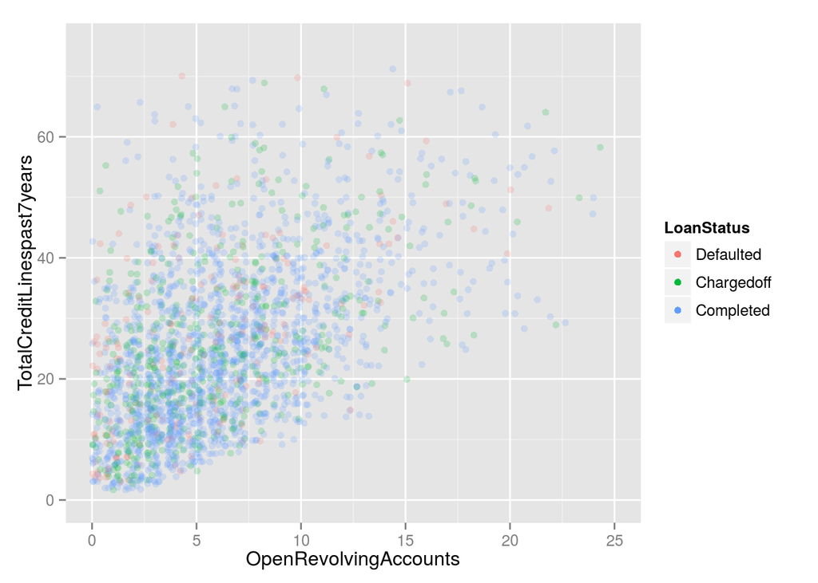

An third example of a relatively strongly correlated pair is TotalCreditLinespast7years and SqrtIncomeLoanAmountRatio. More of the separation of loans by status is accomplished by the synthetic column SqrtIncomeLoanAmountRatio.

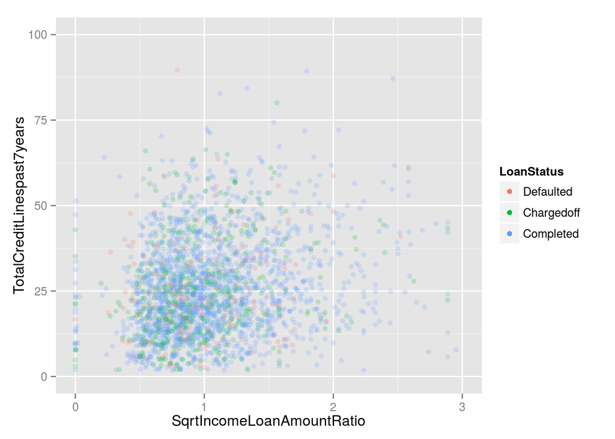

A poorly correlated pair is comprised of CurrentDelinquencies and TotalCreditLinespast7years. The separation is accomplished more by dependence on CurrentDelinquencies than by TotalCreditLinespast7years.

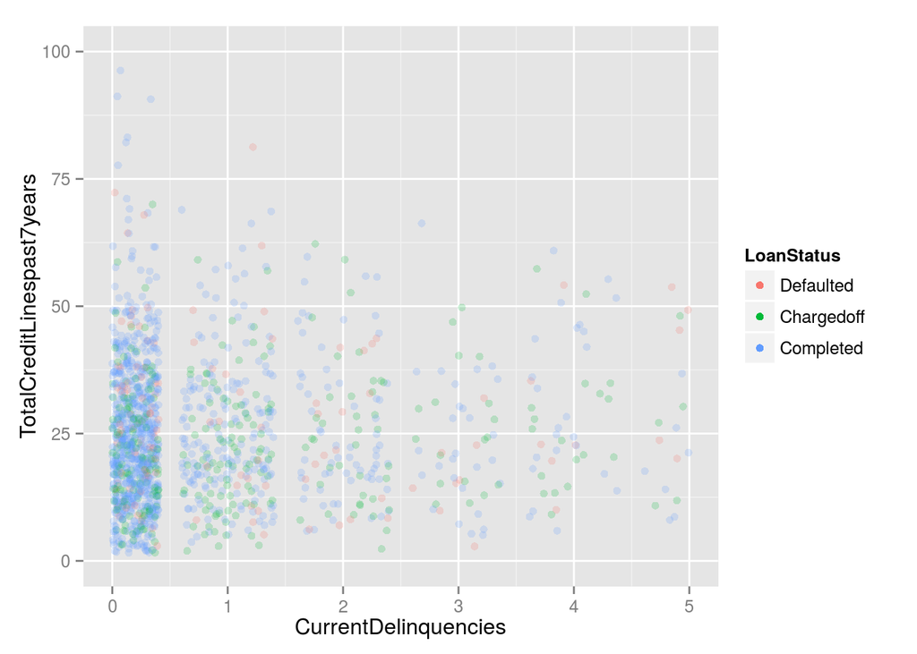

The logistic model fit (discussed near the end) correlates with credit score. This is not surprising, because credit score is a component of the model. The separation by loan status is more horizontal than vertical. This makes sense, because the model fit should be stronger than CreditScoreRangeUpper.

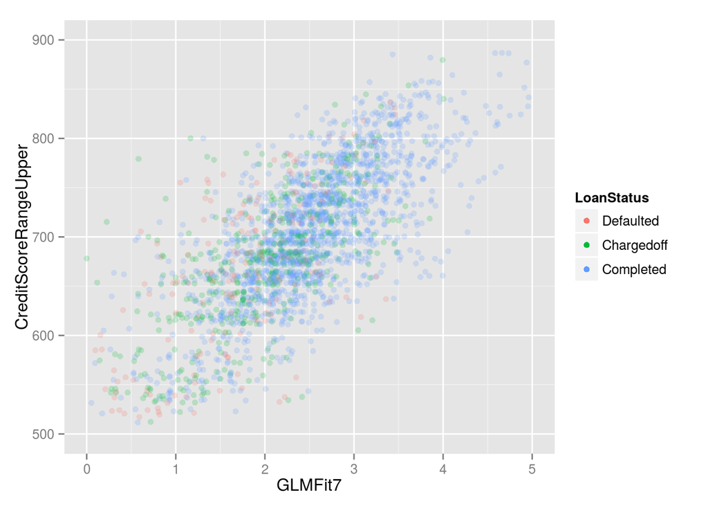

# Multivariate Analysis

### Talk about some of the relationships you observed in this part of the investigation. Were there features that strengthened each other in terms of looking at your feature(s) of interest?

ActualYield and EstimatedEffectiveYield are strongly correlated. Prosper’s estimated effective yield overstates the values of its loans. The scatterplot, colored with Loan Status, displays banding that correlates with the estimated yield. This is an obvious relationship as the loan terms are set at the same time as the effective yiel is calculated.

There are actually two bands of correlation between ActualYield and EstimatedEffectiveYield. These probably correspond to loans orginated before and after 2009.

No single variable other than the credit scores predicted loan default. Most column pairs that were examined were no better at predicting loan default. There are hints that BankcardUtilization and DebtToIncomeRatio might help. Real progress on the problem was not made until models were tried.

### Were there any interesting or surprising interactions between features?

Successively adding CreditScoreRangeUpper, OpenRevolvingAccounts, InquiriesLast6Months, SqrtIncomeLoanAmountRatio, TotalCreditLinespast7years, CurrentDelinquencies, DelinquenciesLast7Years, and OpenRevolvingMonthlyPayment generates a sequence of models that predict whether or not a loan is in Defaulted or Chargedoff as opposed to Completed status.

### OPTIONAL: Did you create any models with your dataset? Discuss the strengths and limitations of your model.

Using a subset of the loans that included only those that included defaulted and completed loans, I attempted to use various combinations of variables to predict loan defaults. The R function for logistic regression is glm with family set to binomial. The quality of the fit was judged by comparing the residual deviance to the null deviance in the output.

As a base point, logistic regression was used where the only independent variable is CreditScoreRangeUpper.

```
##
## Call:
## glm(formula = Completed ~ CreditScoreRangeUpper, family = binomial,
##     data = loansCompDef)
##
## Deviance Residuals:
##     Min       1Q   Median       3Q      Max
## -2.7999   0.3149   0.4113   0.5342   2.8400
##
## Coefficients:
##                         Estimate Std. Error z value Pr(>|z|)
## (Intercept)           -4.1897315  0.1369742  -30.59   <2e-16 ***
## CreditScoreRangeUpper  0.0092029  0.0002059   44.69   <2e-16 ***
## ---
## Signif. codes:  0 '***' 0.001 '**' 0.01 '*' 0.05 '.' 0.1 ' ' 1
##
## (Dispersion parameter for binomial family taken to be 1)
##
##     Null deviance: 30362  on 42549  degrees of freedom
## Residual deviance: 27929  on 42548  degrees of freedom
##   (542 observations deleted due to missingness)
## AIC: 27933
##
## Number of Fisher Scoring iterations: 5
```

The difference $Residual Deviance - Null Deviance$ reported is 2430.

By trial and error among the variables that are pulled from the borrower’s credit report and excluding the credit score, it was found that OpenRevolvingAccounts, InquiriesLast6Months, LoanOriginalAmount/StatedMonthlyIncome are reasonable predictors.

```
##
## Call:
## glm(formula = Completed ~ OpenRevolvingAccounts + InquiriesLast6Months +
##     SqrtIncomeLoanAmountRatio, family = binomial, data = loansCompDef,
##     na.action = na.omit)
##
## Deviance Residuals:
##     Min       1Q   Median       3Q      Max
## -2.8792   0.3773   0.4370   0.4932   4.1697
##
## Coefficients:
##                            Estimate Std. Error z value Pr(>|z|)
## (Intercept)                1.688120   0.043899  38.454   <2e-16 ***
## OpenRevolvingAccounts      0.032600   0.003733   8.733   <2e-16 ***
## InquiriesLast6Months      -0.175758   0.004594 -38.258   <2e-16 ***
## SqrtIncomeLoanAmountRatio  0.570044   0.035682  15.976   <2e-16 ***
## ---
## Signif. codes:  0 '***' 0.001 '**' 0.01 '*' 0.05 '.' 0.1 ' ' 1
##
## (Dispersion parameter for binomial family taken to be 1)
##
##     Null deviance: 30217  on 42471  degrees of freedom
## Residual deviance: 28439  on 42468  degrees of freedom
##   (620 observations deleted due to missingness)
## AIC: 28447
##
## Number of Fisher Scoring iterations: 5
```

The difference $Residual Deviance - Null Deviance$ reported is 1780. This is almost as good as the analysis using credit scores with the largest contribution coming from the count of credit report inquiries made in the last 6 months.

Adding all variables from the credit score group that actually caused the deviance difference to improve, the following model was arrived at:

```
##
## Call:
## glm(formula = Completed ~ CreditScoreRangeUpper + OpenRevolvingAccounts +
##     InquiriesLast6Months + SqrtIncomeLoanAmountRatio + TotalCreditLinespast7years +
##     CurrentDelinquencies + DelinquenciesLast7Years + OpenRevolvingMonthlyPayment,
##     family = binomial, data = loansCompDef)
##
## Deviance Residuals:
##     Min       1Q   Median       3Q      Max
## -3.2387   0.2725   0.3756   0.4836   3.4849
##
## Coefficients:
##                               Estimate Std. Error z value Pr(>|z|)
## (Intercept)                 -3.995e+00  1.868e-01 -21.381  < 2e-16 ***
## CreditScoreRangeUpper        8.386e-03  2.639e-04  31.782  < 2e-16 ***
## OpenRevolvingAccounts        2.125e-02  5.057e-03   4.202 2.64e-05 ***
## InquiriesLast6Months        -1.209e-01  4.931e-03 -24.511  < 2e-16 ***
## SqrtIncomeLoanAmountRatio    1.013e+00  4.074e-02  24.876  < 2e-16 ***
## TotalCreditLinespast7years  -9.103e-03  1.440e-03  -6.319 2.63e-10 ***
## CurrentDelinquencies        -1.113e-01  6.916e-03 -16.087  < 2e-16 ***
## DelinquenciesLast7Years      9.992e-03  1.754e-03   5.698 1.22e-08 ***
## OpenRevolvingMonthlyPayment -5.071e-04  4.003e-05 -12.669  < 2e-16 ***
## ---
## Signif. codes:  0 '***' 0.001 '**' 0.01 '*' 0.05 '.' 0.1 ' ' 1
##
## (Dispersion parameter for binomial family taken to be 1)
##
##     Null deviance: 29886  on 42224  degrees of freedom
## Residual deviance: 25704  on 42216  degrees of freedom
##   (867 observations deleted due to missingness)
## AIC: 25722
##
## Number of Fisher Scoring iterations: 5
```

The difference $Residual Deviance - Null Deviance$ reported is 4182.

# Final Plots and Summary

### Actual Yield < EstimatedEffectiveYield

The estimated yields that Prosper offers for its loans are systematically higher than the yields actually attained. The densities for the two are plotted on top of one another below. The density is a normalized histogram so the superposition makes mathematical sense. The density for the actual yield peaks at lower values

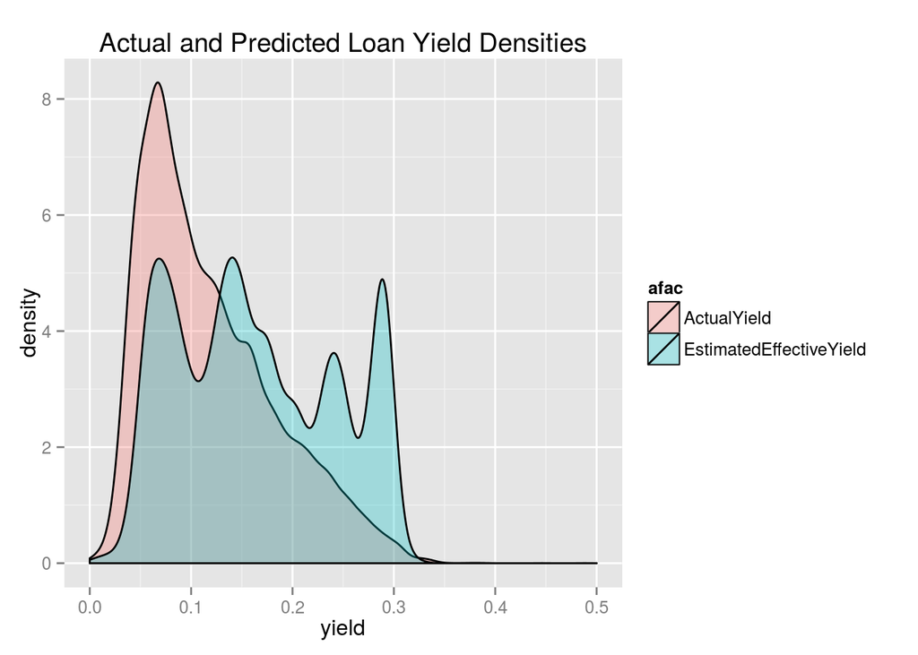

The reason for the discrepancy between actual and predicted yields is that a high percentage of Prosper loans are paid off early. In order to achieve the returns advertised by Prosper, lenders should be prepared to reinvest prepaid loan proceeds immediately on receipt.

The synthetic column CompleteDays divided by the term of the loan measures how close to full term the loan is when it is in Completed status. The histogram of this formula shows that many loans go to full term, but the majority are paid off early.

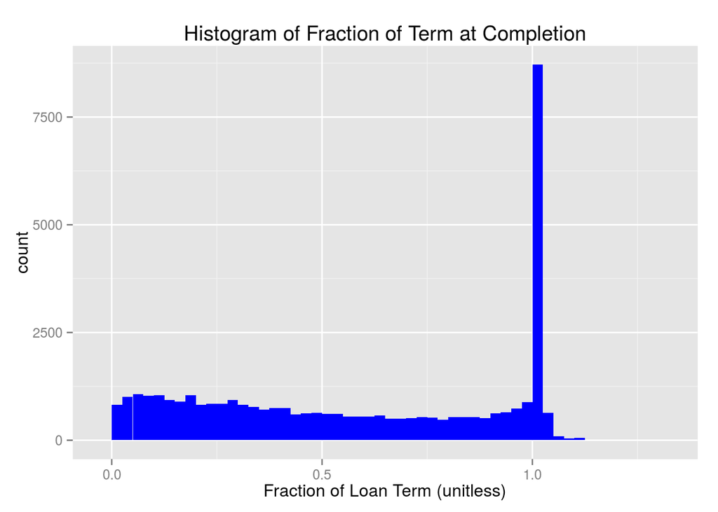

### Credit Worthiness Over Time Using a Model Fit

Predicting loan default and chargeoff status using variables and pairs of variables in the raw data set did not work. Combinations of variables using a logistic regression fit discovered a combination that performs better than credit scores. In the plot below, the defaults and chargeoffs show up as red and green dots while successfully completed loans are described by blue dots. Red and green dots appear in general below the blue dots, so the fit does tend to divide loans into unsucccessful and successful categories.

A model fit, GLMFit7, was obtained that is a linear combination of the features CreditScoreRangeUpper, OpenRevolvingAccounts, InquiriesLast6Months, SqrtIncomeLoanAmountRatio, TotalCreditLinespast7years, CurrentDelinquencies, DelinquenciesLast7Years, and OpenRevolvingMonthlyPayment to predict loan disposition. The data for the fit is the subset of the data that was in ‘Completed’, “Chargedoff”, and ‘Defaulted’ loan status. The model attempts to map the input attributes to 1 for ‘Completed’ and 0 for ‘Chargedoff’ and ‘Defaulted’ loans.

The target of the fit is a synthetic variable that takes the values 0 and 1. The predictions final plot below is a plot of inv.logit(GLMFit7) versus time. The result of applying inv.logit is a floating point number between 0 and 1. Very roughly, the vertical axis is related to the “probability” of successful loan completion. To avoid overplotting, a low power of this “probability” is used as a vertical plot axis.

The fact that orange (Defaulted) points plot below green (Chargedoff) points and these plot below blue (Completed) points is the point of the analysis. The separation between unsuccessful and successful zones in the scatterplot is not sharp and varies from year to year.

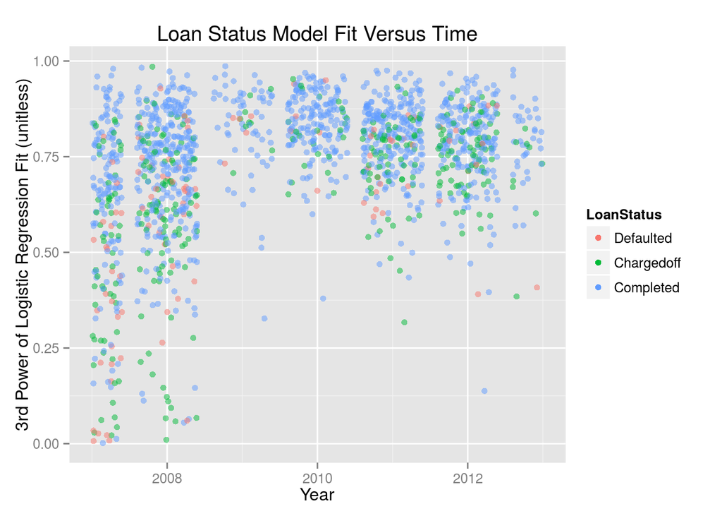

# Reflection

I explored two questions: (1) are Prosper’s estimates of loan yield accurate and (2) is there a good way to predict loan chargeoff and default?

Estimating the actual yield was straighforward. Chasing down the definition of yield from Prosper’s web pages, determining that loans are compounded monthly, and applying the interest rate formula was all that was required to calculate the true yield.

The Udacity lectures advocate using alpha and geom_jitter to counter overplotting. For some datasets, subsampling dataframes by row yields crisper plots that are freer of overplotted points. The technique works as long as there are no systematic trends in the dataframe that is getting sampled. The R code ‘ggplot(df[sample(nrow(df),n),],aes_string(x=x,y=y))’ accomplishes this task.

To finish off the analysis of actual vs predicted yield, would require applying an interest rate to the value of the funds at loan completion and projecting the earnings out to the full term of each of the loans. Picking the appropriate interest rate at the time the loans finished is the hard part of this calculation.

Predicting loan default proved to be much harder than I thought it would be. I started off by producing a massive number of scattergrams and time history plots looking for correlations or variables that separated successful and unsuccessful loans.

This effort failed. Techniques of descriptive statistics alone were not really up to the task of predicting loan default. To crack the problem required model fitting (many iterations) to determine a linear combination of the available features to uncover hidden patterns. Scatterplots are two or three (with color). The space of attributes that predicts loan defaults is closer to ten.

The strategy that eventually worked was to invert the order of operations laid out for Project 3. That is, to start out with a model fit and then generate scattergrams that validate the model. By adding more and more variables, a sequence of models were discovered that eventually was able to successfully separate out a large fraction of the successful loans from the successful loans.

Extensions to the loan status prediction problem include scaling the input variables so that they are unitless, trimming outliers before model fitting, getting real confidence intervals on the coefficients.